# MA 132 SP23 Enrollment Prediction

2023-10-05

Import Relevant libraries

```r
library(tidyverse)
library(here)
library(janitor)
library(stringr)
library(skimr)
library(scales)
```

Import data set

```r
thisfile <- here("data_raw", "CU_ACAD_DEPT_WHEN_OFF_ENRL.csv")

df1 <- read_csv(thisfile) |> clean_names()
```

Filter only MA 132

```r
df_calc <- df1 |>
  filter(subject == "MA" & (catalog == "132" | catalog == "131") & component == "LEC")
```

Remove the columns that are not relevant.

```r
df3 <- df_calc |>
  select(-acad_org, -current_status, -subject, -course_id, -section, -title, -component, -instructor)
```

Deleting current irrelevant columns and getting the total amount of students for MA132 in each semester.

```r
df4 <- df_calc |>
  select(-acad_org, -current_status, -subject, -course_id, -section, -title, -component, -instructor) |>
  group_by(catalog, term_7, term_8, tot_enrl) |>
  summarise(tot_enrl = sum(tot_enrl)) |>
  mutate(cum_enrl = cumsum(tot_enrl))
```

Filtering only MA 131 and MA 132 and putting them into their own data frames, respectively.

```r
df131 <- df4 |>
  filter(catalog == 131)

df132 <- df4 |>
  filter(catalog == 132)
```

This data frame contains only the number of sections for each semester.

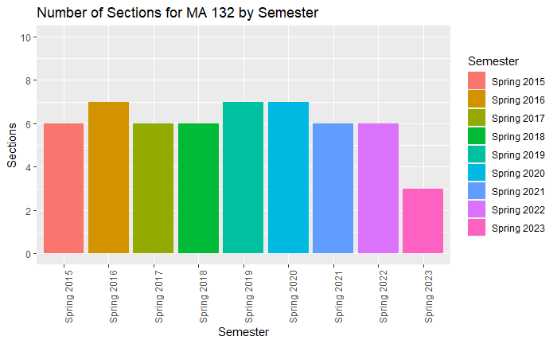

```r
 df132_spring <- df132 |>
  filter(str_detect(term_8, c("Spring")))  |>
  filter(!(term_8 == "Spring 2024"))

df132_sections <- df132_spring |>
  filter(catalog == 132) |>
  filter(str_detect(term_8, c("Spring"))) |>
  count(term_8, sort = FALSE) |>
  filter(!(term_8 == "Spring 2024"))



ggplot(df132_sections, aes(x = fct_inorder(term_8), y = n, fill = term_8)) + geom_col() + theme(axis.text.x = (element_text(angle = 90))) + labs(title = "Number of Sections for MA 132 by Semester") + xlab("Semester") + ylab("Sections") + scale_fill_discrete(name = "Semester") + scale_y_continuous(breaks = pretty_breaks(), limits = c(0,10))
```

```r
summary(df132_sections)
```

```
    catalog        term_7        term_8                n
 Min.   :132   Min.   :4152   Length:9           Min.   :3
 1st Qu.:132   1st Qu.:4172   Class :character   1st Qu.:6
 Median :132   Median :4192   Mode  :character   Median :6
 Mean   :132   Mean   :4192                      Mean   :6
 3rd Qu.:132   3rd Qu.:4212                      3rd Qu.:7
 Max.   :132   Max.   :4232                      Max.   :7
```

Here we see a bar chart of the number sections per semester. The average amount of sections offered is 6.

This data frame contains only the spring semester MA 132 sections and their total students enrolled, respectively.

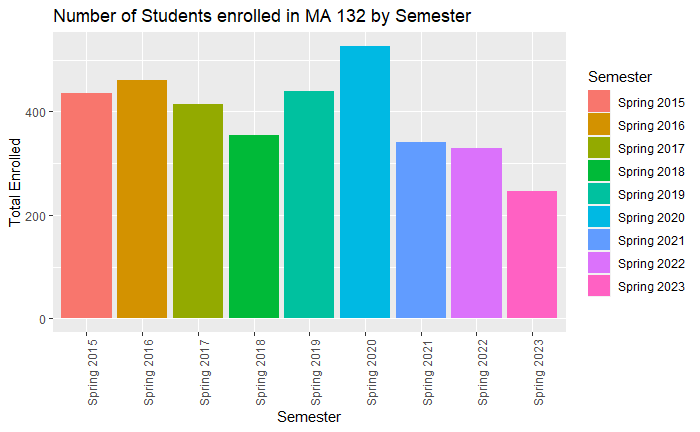

```r
df132_spring <- df132 |>
  filter(str_detect(term_8, c("Spring")))  |>
  filter(!(term_8 == "Spring 2024")) |>
  summarise(cum_sum = sum(tot_enrl))
ggplot(df132_spring, aes(x = fct_inorder(term_8), y = cum_sum, fill = term_8)) + geom_col() + theme(axis.text.x = (element_text(angle = 90))) + labs(title = "Number of Students enrolled in MA 132 by Semester") + xlab("Semester") + ylab("Total Enrolled") + scale_fill_discrete(name = "Semester")
```

This brings up a statistical summary of the columns in df132.

```r
summary(df132_spring)
```

```
    catalog        term_7        term_8             cum_sum
 Min.   :132   Min.   :4152   Length:9           Min.   :246.0
 1st Qu.:132   1st Qu.:4172   Class :character   1st Qu.:341.0
 Median :132   Median :4192   Mode  :character   Median :414.0
 Mean   :132   Mean   :4192                      Mean   :394.2
 3rd Qu.:132   3rd Qu.:4212                      3rd Qu.:440.0
 Max.   :132   Max.   :4232                      Max.   :527.0
```

Here, we will take make a data frame of just Fall MA 131 to find the total enrollment for each semester

```r
 df131_fall <- df131 |>
  filter(str_detect(term_8, c("Fall")))  |>
  filter(!(term_8 == "Fall 2024")) |>
  summarise(cum_sum = sum(tot_enrl))
```

This is a bar chart of the total enrollment in MA 131 by Semester

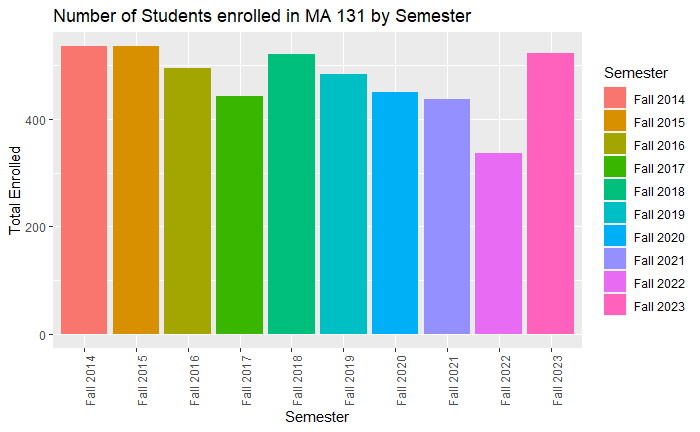

```r
ggplot(df131_fall, aes(x = fct_inorder(term_8), y = cum_sum, fill = term_8)) + geom_col() + theme(axis.text.x = (element_text(angle = 90))) + labs(title = "Number of Students enrolled in MA 131 by Semester") + xlab("Semester") + ylab("Total Enrolled") + scale_fill_discrete(name = "Semester")
```

Modifying the code used in the asynchronous lecture, we can find the difference between Spring MA132 enrollment and the Fall 131 enrollment added together with the Fall 132.

```r
dfVideo1 <- df1 |>
  filter(subject=="MA") |>
  select(-acad_org,-current_status,-course_id,-title) |>
  filter(component=="LEC", catalog %in% c(131,132) ) |>
  mutate(catalog=as.character(catalog)) |>
 separate_wider_delim(term_8," ",names = c("semester", "yr"))|>
  filter(!(semester=="Summer")) |>
  select(-subject) |>
  mutate(ay=((term_7-4000)/10) |> round()) |> # this will denote the academic year
  select(-term_7,-yr,-component)|>
  slice_head(n=1,by=c("catalog","section","semester","ay")) |> # Gets ride of any duplicate instructors for the same semester to decreased adding in students twice
  select(-instructor) |>
  summarise(tot_enrl = sum(tot_enrl), .by=c("catalog","semester","ay")) |>
  pivot_wider(id_cols = ay,names_from = c("semester","catalog"),values_from = tot_enrl) |>
  clean_names() |>
  select(-spring_131) |>
  filter(!row_number() %in% 10) |>
  mutate(diff = spring_132 - fall_131 - fall_132) |>
  select(-ay, -fall_131, -fall_132, -spring_132)
```

We then can see a statistical summary of the differences between the Spring and Fall of the same academic year.

```r
summary(dfVideo1)
```

```
      diff
 Min.   :-271.0
 1st Qu.:-254.0
 Median :-252.0
 Mean   :-249.3
 3rd Qu.:-240.0
 Max.   :-235.0
```

Taking the median or mean, you can subtract that from the total enrollment of the current MA131.

```r
mean <- -249.3
median <- -252
current131 <- 523

predicted_mean <- current131 + mean
predicted_median <- current131 + median
paste("Predicted amount of students using the mean:", predicted_mean)
```

```
[1] "Predicted amount of students using the mean: 273.7"
```

```r
paste("Predicted amount of students using the median:", predicted_median)
```

```
[1] "Predicted amount of students using the median: 271"
```

```r
dfVideo2 <- df1 |>
  filter(subject=="MA") |>
  select(-acad_org,-current_status,-course_id,-title) |>
  filter(component=="LEC", catalog %in% c(131,132) ) |>
  mutate(catalog=as.character(catalog)) |>
  separate_wider_delim(term_8," ",names = c("semester", "yr")) |>
  filter(!(semester=="Summer")) |>
  select(-subject) |>
  mutate(ay=((term_7-4000)/10) |> round()) |>
  select(-term_7,-yr,-component) |>
  slice_head(n=1,by=c("catalog","section","semester","ay"))|>
  select(-instructor) |>
  summarise(tot_enrl = sum(tot_enrl), .by=c("catalog","semester","ay")) |>
  pivot_wider(id_cols = ay,names_from = c("semester","catalog"),values_from = tot_enrl) |>
  clean_names() |>
  select(-spring_131) |>
  filter(!row_number() %in% 10) |>
  mutate(fall_enrl = fall_131 +fall_132)
ggplot(dfVideo2, aes(x = fall_enrl, y = spring_132)) +
  geom_point() + geom_smooth(method = lm, se = FALSE) + labs(title = "MA 132 Spring Enrollment Predicted by MA 131 Fall Enrollment", x = "MA 131 Fall", y = "MA 132 Spring")
```

[output not shown]